# 第1章 回帰モデルとスパース推定

Osamu, MORIMOTO

2023-10-12

## 1. 正則化回帰で過学習を抑制できるケース。

### 準備

最初にこれから使用するパッケージを一通り呼び出しておく。

```r
if (!require("pacman")) {install.packages("pacman")} # パッケージ管理
pacman::p_load(
  conflicted,   # 関数名の衝突防止
  tidyverse,    # モダンなデータ操作
  glmnetUtils,  # 正則化回帰。テキストと違うが、こちらの方がformulaで書けるのでこちらを使う
  rsample,      # 学習データ、検証データ分割
  plotmo,       # glmnetの結果のλの変化と回帰係数の関係図
  patchwork,    # ggplot2の図をレイアウトする
  MLmetrics,    # 評価指標
  withr,        # 乱数種固定
  janitor,      # データクリーニング
  broom         # 回帰の結果をtidyにする
  )
```

### 正則化回帰で過学習を抑制できるケース。

#### 過学習するケース

まず、過学習が発生するケースを考える。

ここでは[carsデータセット](https://stat.ethz.ch/R-manual/R-devel/library/datasets/html/cars.html)を用いた多項式回帰を想定する。

carsは自動車の速度と制動距離の関係を測定したデータセットで、speedとdistの2つの変数からなる。

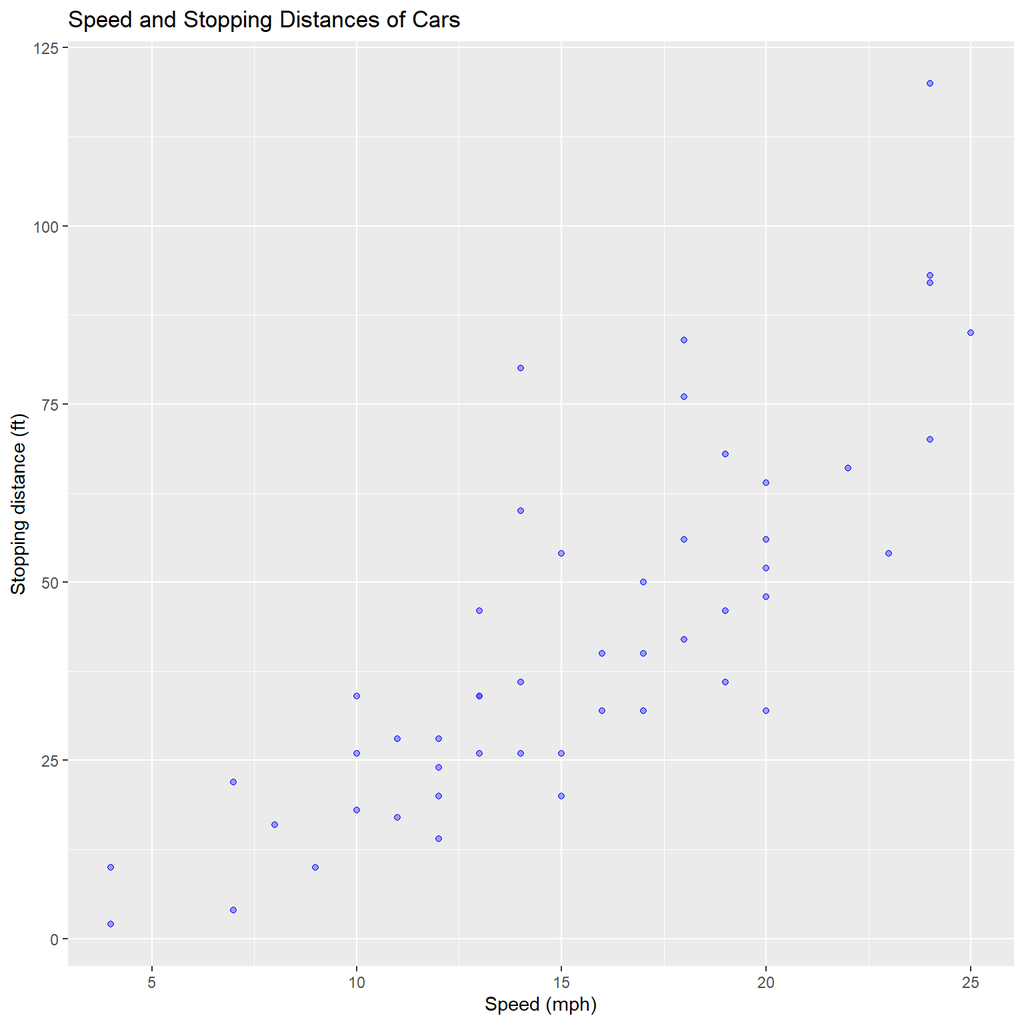

```r
cars |>
  ggplot(aes(x = speed, y = dist)) +
  geom_point(shape = 21, color = "blue", fill = "#0000FF55") +
  labs(
    title = "Speed and Stopping Distances of Cars",
    x = "Speed (mph)",
    y = "Stopping distance (ft)"
  )
```

ここで速度から制動距離を推定する多項式回帰のモデルを作る。

まず解釈しやすいようにデータを標準化する。

```r
cars_std <- cars |>
  scale() |>
  as.data.frame()
```

学習用データと検証用データに分ける。

「サンプルサイズが小さすぎる」と警告が出るが実験なので今回は無視する。

```r
cars_split_data <- cars_std |>
  initial_split(prop = 0.5, strata = "dist") |>
  with_seed(2, code = _)
```

```
## Warning: The number of observations in each quantile is below the recommended threshold of 20.
## • Stratification will use 2 breaks instead.
```

```r
# 学習用データ生成
cars_train <- cars_split_data |>
  training()

# 検証用データ生成
cars_test <- cars_split_data |>
  testing()
```

学習用データで回帰モデルを作る。

まず、単純な線形回帰。

y = a + bx

```r
lm1 <- lm(dist ~ speed, data = cars_train)

lm1 |>
  summary()
```

```
##
## Call:
## lm(formula = dist ~ speed, data = cars_train)
##
## Residuals:
##      Min       1Q   Median       3Q      Max
## -1.10552 -0.40211  0.00069  0.23843  1.67867
##
## Coefficients:
##             Estimate Std. Error t value Pr(>|t|)
## (Intercept) -0.04589    0.12558  -0.365    0.718
## speed        0.83375    0.12619   6.607 9.67e-07 ***
## ---
## Signif. codes:  0 '***' 0.001 '**' 0.01 '*' 0.05 '.' 0.1 ' ' 1
##
## Residual standard error: 0.6279 on 23 degrees of freedom
## Multiple R-squared:  0.6549, Adjusted R-squared:  0.6399
## F-statistic: 43.65 on 1 and 23 DF,  p-value: 9.673e-07
```

次に2次式。

y = a + bx + bx^2

```r
lm2 <- lm(dist ~ speed + I(speed^2), data = cars_train)

lm2 |>
  summary()
```

```
##
## Call:
## lm(formula = dist ~ speed + I(speed^2), data = cars_train)
##
## Residuals:
##     Min      1Q  Median      3Q     Max
## -1.0891 -0.3242 -0.1298  0.2191  1.4767
##
## Coefficients:
##             Estimate Std. Error t value Pr(>|t|)
## (Intercept)  -0.1561     0.1642  -0.951    0.352
## speed         0.8448     0.1264   6.683 1.02e-06 ***
## I(speed^2)    0.1112     0.1069   1.040    0.310
## ---
## Signif. codes:  0 '***' 0.001 '**' 0.01 '*' 0.05 '.' 0.1 ' ' 1
##
## Residual standard error: 0.6268 on 22 degrees of freedom
## Multiple R-squared:  0.6711, Adjusted R-squared:  0.6412
## F-statistic: 22.44 on 2 and 22 DF,  p-value: 4.873e-06
```

1次から9次までのモデルのあてはまりを可視化して確認してみる。

9次の式だとこんな感じ。

y = a + bx + bx^2 + bx^3 + bx^4 + bx^5 + bx^6 + bx^7 + bx^8 + bx^9

次数が増えると過学習している様子が分かる。

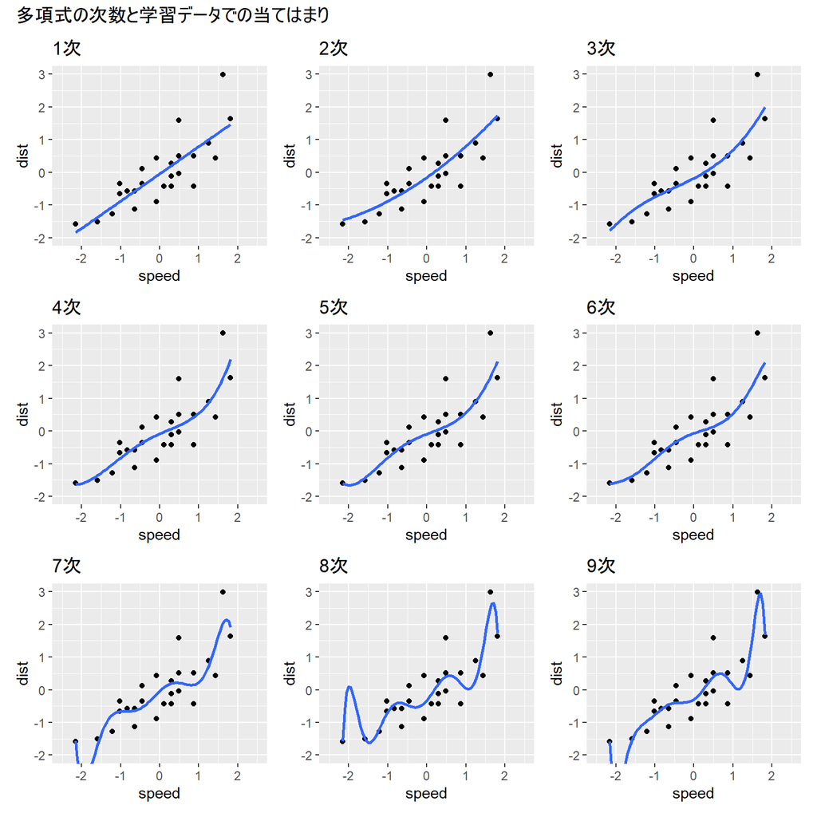

```r
models <- map(1:9,
  \(x) lm(
    as.formula(paste0("dist ~ poly(speed, degree = ", x, ", raw=TRUE)")),
    data = cars_train
    )
  )

my_plot <- function(formula) {
  cars_train |>
    ggplot(aes(x = speed, y = dist)) +
    geom_point() +
    geom_smooth(method = "lm", formula = formula, se = FALSE) +
    coord_cartesian(xlim = c(-2.5, 2.5), ylim = c(-2, 3)) +
    labs(title = paste0(parse_number(formula), "次"))
  }

# 各モデルのあてはまりを図で確認
ps <- map(1:9, \(x) my_plot(paste0("y ~ poly(x, degree = ", x, ", raw=TRUE)")))

wrap_plots(ps) +
  plot_layout(ncol = 3) +
  plot_annotation(title = "多項式の次数と学習データでの当てはまり")
```

決定係数を確認すると、次数が増えるほど見かけ上のあてはまりはどんどん良くなっている。

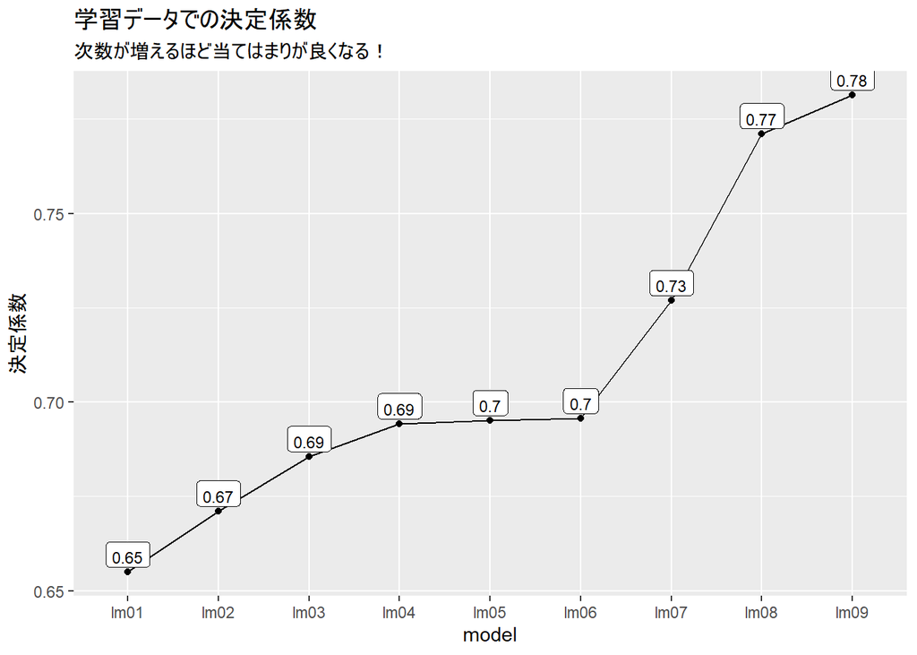

```r
data.frame(
  model = paste0("lm", formatC(1:9, width = 2, flag = "0")) |> as.factor(),
  R2 = map_dbl(1:9, \(x) R2_Score(models[[x]]$fitted.values, cars_train$dist))
  ) |>
  pivot_longer(!model) |>
  ggplot(
    aes(x = model, y = value, group = name, label = round(value, 2))
  ) +
  geom_line() +
  geom_point() +
  geom_label(vjust = -0.2, size = 3) +
  labs(
    title = "学習データでの決定係数",
    subtitle = "次数が増えるほど当てはまりが良くなる！",
    y = "決定係数"
  ) +
  theme(legend.position = "none")
```

#### 汎化性能を確認する。

できたモデルに検証用データを当てはめて汎化性能を確認する。

学習データでは次数が増えると評価指標も良くなるが、検証データでは次数が増えると評価指標が悪化する。これが過学習。

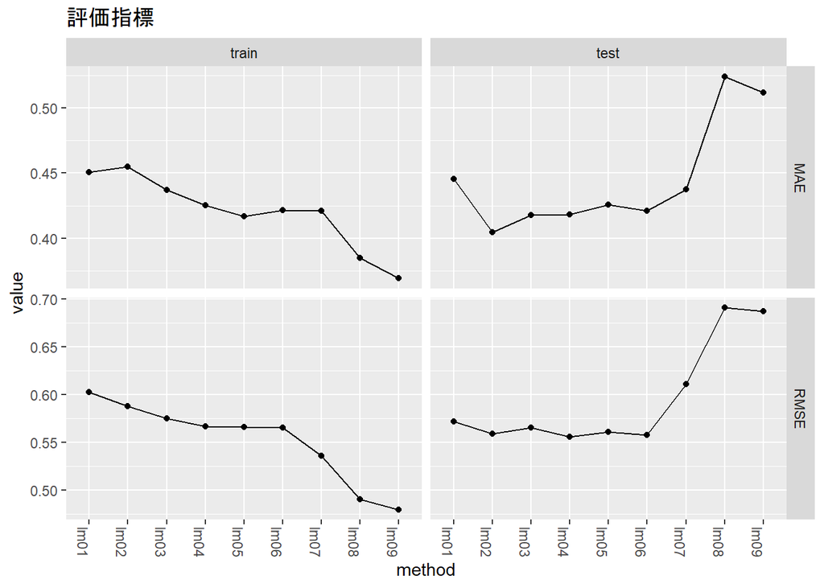

```r
tibble(
  method = paste0("lm", formatC(1:9, width = 2, flag = "0")),
  train_MAE = models |>
    map_dbl(\(x) MLmetrics::MAE(predict(x), cars_train$dist)),
  test_MAE = models |>
    map_dbl(\(x) MLmetrics::MAE(predict(x, cars_test), cars_test$dist)),
  train_RMSE = models |>
    map_dbl(\(x) MLmetrics::RMSE(predict(x), cars_train$dist)),
  test_RMSE = models |>
    map_dbl(\(x) MLmetrics::RMSE(predict(x, cars_test), cars_test$dist))
  ) |>
  pivot_longer(!method) %>%
  mutate(
    type = stringr::str_split(.$name, "_", simplify = TRUE)[, 1] |>
      factor(levels = c("train", "test")),
    measure = stringr::str_split(.$name, "_", simplify = TRUE)[, 2] |>
      factor(levels = c("MAE", "RMSE"))
  ) |>
  ggplot(aes(x = method, y = value, group = 1)) +
  geom_line() +
  geom_point() +
  facet_grid(vars(measure), vars(type), scales = "free") +
  labs(title = "評価指標") +
  theme(axis.text.x = element_text(angle = 270, hjust = 1))
```

#### 正則化回帰で過学習を抑制する

正則化回帰を使うと偏回帰係数の大きさが正則化項によって大きくなり過ぎないように抑制され、過学習を防ぐことができる。

なお、説明変数の単位（スケール）によって正則化項の大きさが変わってしまうのを防ぐため、説明変数は標準化する必要がある。

ただし、Rで実行するにあたっては関数内で標準化の処理をしてくれるので事前に標準化する処理は必要ない。

とにかく、先ほどの9次の多項式回帰モデルを使って、正則化回帰（LASSO回帰）を試して偏回帰係数を確認しましょう。

まず従来の線形回帰。

```r
car_fit_lm <- lm(
  dist ~ poly(speed, degree = 9, raw = TRUE),
  data = cars_train
  )

car_fit_lm |>
  tidy()
```

| term | estimate | std.error | statistic | p.value |
| --- | --- | --- | --- | --- |
| (Intercept) | -0.2940264 | 0.3005240 | -0.97837907 | 0.34340366 |
| poly(speed, degree = 9, raw = TRUE)1 | 0.8093888 | 1.0016682 | 0.80804085 | 0.43169587 |
| poly(speed, degree = 9, raw = TRUE)2 | 1.9877004 | 1.8034158 | 1.10218642 | 0.28775168 |
| poly(speed, degree = 9, raw = TRUE)3 | 0.2754446 | 3.7728838 | 0.07300638 | 0.94276566 |
| poly(speed, degree = 9, raw = TRUE)4 | -3.7661163 | 2.5504135 | -1.47666889 | 0.16044942 |
| poly(speed, degree = 9, raw = TRUE)5 | -1.4687495 | 4.1524448 | -0.35370716 | 0.72848073 |
| poly(speed, degree = 9, raw = TRUE)6 | 2.1097678 | 1.2021558 | 1.75498692 | 0.09965838 |
| poly(speed, degree = 9, raw = TRUE)7 | 1.0111429 | 1.6509880 | 0.61244715 | 0.54941462 |
| poly(speed, degree = 9, raw = TRUE)8 | -0.3501240 | 0.1811820 | -1.93244319 | 0.07241437 |
| poly(speed, degree = 9, raw = TRUE)9 | -0.1762851 | 0.2105264 | -0.83735406 | 0.41553625 |

次にLASSO回帰。

glmnet()関数で、`alpha = 1`とするとLASSO回帰になります。

lambdaに謎の数字が入ってますがいったん無視してください。

変数選択されて2つの説明変数しか残っていません。

```r
car_fit_glmnet_L1 <- glmnet(
  dist ~ poly(speed, degree = 9, raw = TRUE),
  data = cars_train, alpha = 1, lambda = 0.1554653
)

car_fit_glmnet_L1 |>
  tidy()
```

| term | step | estimate | lambda | dev.ratio |
| --- | --- | --- | --- | --- |
| (Intercept) | 1 | -0.04204715 | 0.1554653 | 0.6358593 |
| poly(speed, degree = 9, raw = TRUE)1 | 1 | 0.61933033 | 0.1554653 | 0.6358593 |
| poly(speed, degree = 9, raw = TRUE)3 | 1 | 0.02443816 | 0.1554653 | 0.6358593 |

あてはまり具合を可視化してみましょう。

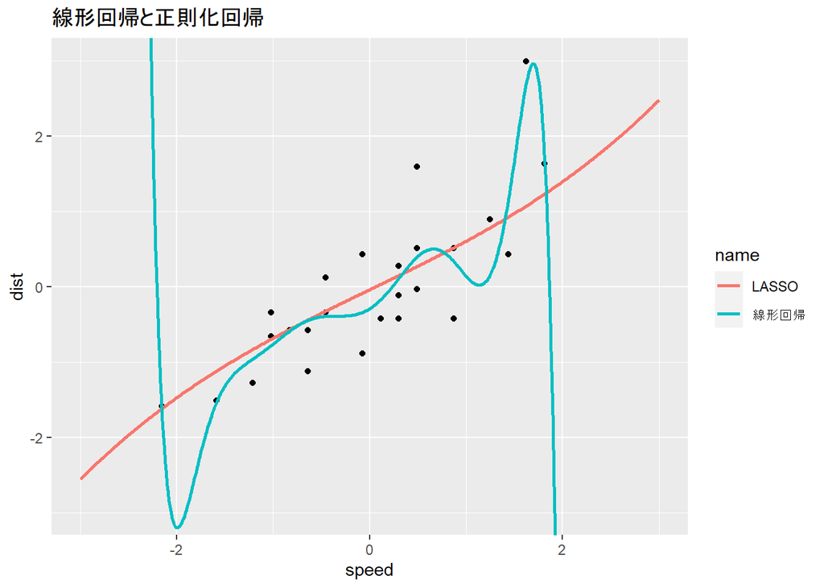

```r
newcars <- data.frame(speed = seq(-3, 3, 0.01))

fitted_df <- tibble(
  LASSO = predict(car_fit_glmnet_L1, newcars),
  線形回帰 = predict(car_fit_lm, newcars)
) |>
  bind_cols(newcars) |>
  pivot_longer(!speed, values_to = "dist")

ggplot() +
  geom_point(data = cars_train, aes(x = speed, y = dist)) +
  geom_line(data = fitted_df, aes(x = speed, y = dist, color = name), linewidth = 1) +
  coord_cartesian(xlim = c(-3, 3), ylim = c(-3,3)) +
  labs(title = "線形回帰と正則化回帰")
```

モデルは同じ9次の多項式でも、正則化項を使うことで過学習を抑えた解が得られていることが分かります。

#### 正則化回帰の実行

正則化回帰を実行する上で検討しなくてはならないのがモデル選択。

- RidgeかLASSOかエラスティックネットか、さらにそのバリエーションか。
- lambdaをどう決めるか
  - クロスバリデーション(CV)で決める
  - 情報量規準で決める

基本的には、やってみて汎化性能を確認して採用するモデルを決めるのが良いと思う。

Rで正則化回帰を実行するには様々なパッケージがある。テキストではglmnetパッケージが使われているが、今回はglmnetUtilsを使う。こちらの方がモデルをformulaで書くことができ簡潔に書けるので。

Ridge回帰はglmnet関数でalpha=0を指定すれば実行できる。

lambdaを指定しない場合、自動的に生成された100個のλの値の結果を返す。

```r
car_fit_ridge <- glmnet(
  dist ~ poly(speed, degree = 9, raw = TRUE),
  data = cars_train,
  alpha = 0
  )
```

λと回帰係数の大きさの関係の可視化（解パス(solution path)）。

縦軸が偏回帰係数、横軸がλの大きさ、上の数字は説明変数の数。

λが大きくなると偏回帰係数の大きさが小さくなる様子が分かる

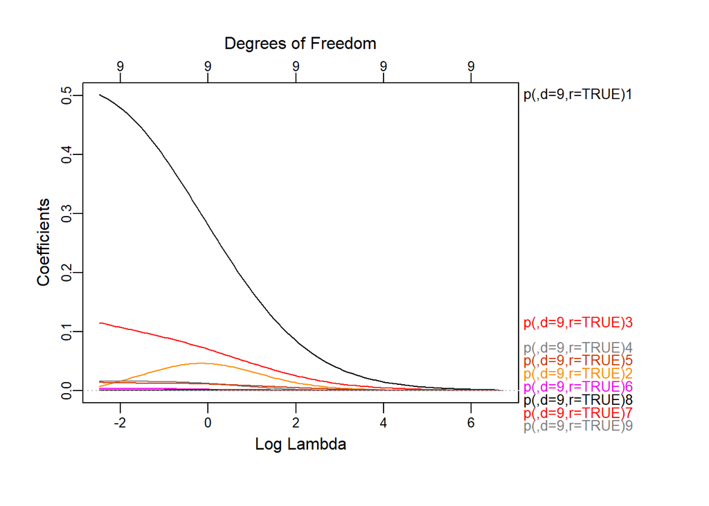

```r
car_fit_ridge |>
  plot_glmnet(xvar = "lambda", label = TRUE)
```

LASSO回帰はglmnet関数でalpha=1を指定すれば実行できる

```r
car_fit_lasso <- glmnet(
  dist ~ poly(speed, degree = 9, raw = TRUE),
  data = cars_train,
  alpha = 1
  )
```

解パス。

λが大きくなると偏回帰係数が小さくなると同時に説明変数の数も減ることが分かる。

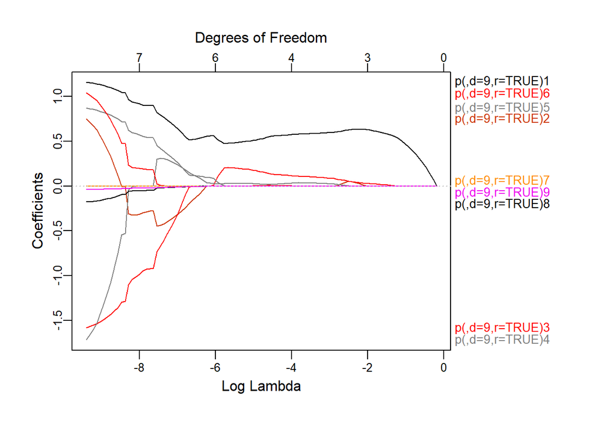

```r
car_fit_lasso |>
  plot_glmnet(xvar = "lambda", label = TRUE)
```

LASSO回帰のバリエーションとして適応的LASSO(Adaptive LASSO) がある。

単に偏回帰係数の絶対値を足すのではなく、説明変数ごとに事前に重みを与える方法である。

適応的LASSOではλを`5/n^(3/4)`とすればオラクル性を満たす。

```r
# 標準化したlmで重み算出
lm_std_coef <- cars_train |>
  scale() |>
  as.data.frame() |>
  lm(dist ~ poly(speed, degree = 9, raw = TRUE), data = _) |>
  tidy() |>
  select(estimate) |>
  slice(-1)

# 適応的ラッソ実行
car_fit_alasso <- cars_train %>%
  glmnet(
    dist ~ poly(speed, degree = 9, raw = TRUE),
    data = .,
    alpha = 1,
    lambda = 5 / nrow(.)^(3 / 4),
    penalty.factor = 1 / abs(lm_std_coef$estimate)
  )
```

#### 適切なλの値を求めたい

まだ、適切なλの値が定まっていない。

λを決めるにはCVで決める方法と情報量規準で決める方法とがある。

##### CVで適切なλを求める

cv.glmnet()関数を使ってCVによる適切なλの値を求めることができる。

適応的LASSOについてもCVでλを求めてみる。

```r
# Ridge
car_fit_ridge_cv <- cv.glmnet(
  dist ~ poly(speed, degree = 9, raw = TRUE),
  data = cars_train,
  alpha = 0,
  nfolds = 5
  ) |>
  with_seed(2, code = _) #乱数種の固定

# LASSO
car_fit_lasso_cv <- cv.glmnet(
  dist ~ poly(speed, degree = 9, raw = TRUE),
  data = cars_train,
  alpha = 1,
  nfolds = 5
  ) |>
  with_seed(2, code = _)

# 適応的LASSO
car_fit_alasso_cv <- cv.glmnet(
  dist ~ poly(speed, degree = 9, raw = TRUE),
  data = cars_train,
  alpha = 1,
  nfolds = 5,
  penalty.factor = 1 / abs(lm_std_coef$estimate)
  ) |>
  with_seed(2, code = _)
```

CVの結果を可視化する。

評価指標が最も小さくなるλの値が適切なλの値と推定される。

なお、よりシンプルなモデルを選びたい場合は最も評価指標が小さくなる値から1標準誤差の範囲で最も大きい値を採用する場合もある（1SE基準）。

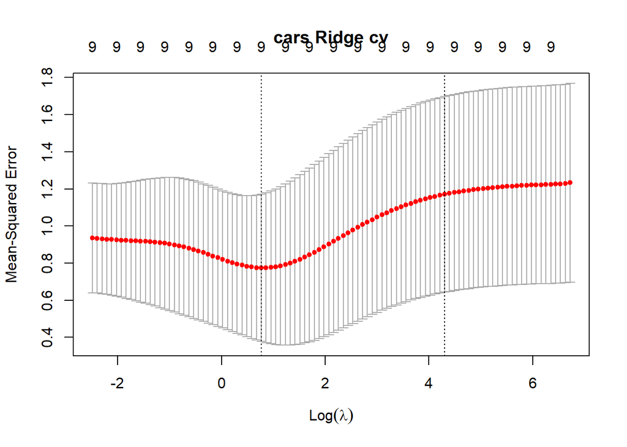

```r
plot(car_fit_ridge_cv, main = "cars Ridge cv")
```

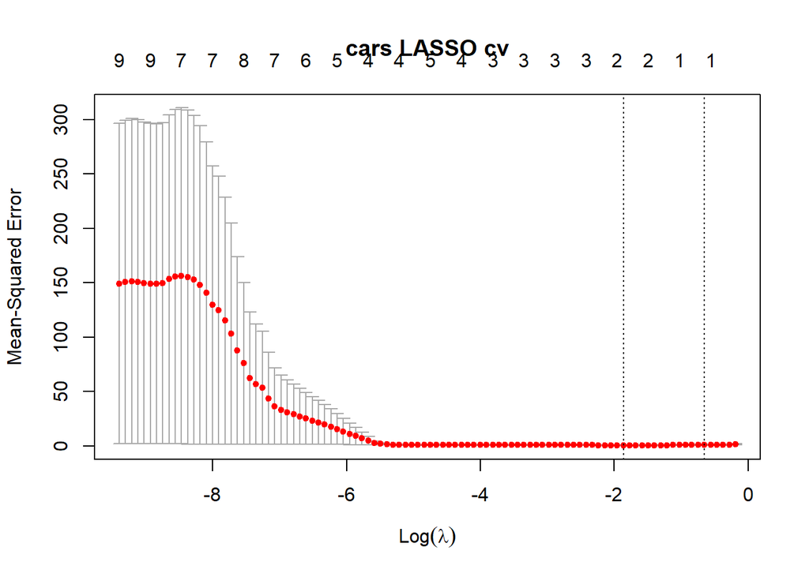

```r
plot(car_fit_lasso_cv, main = "cars LASSO cv")
```

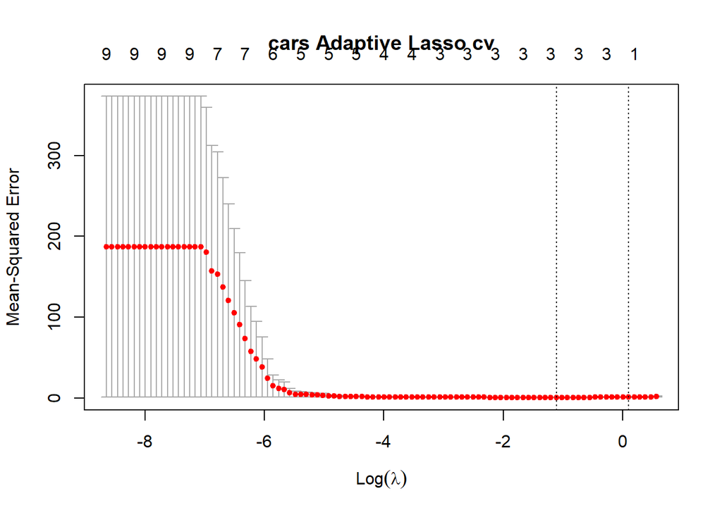

```r
plot(car_fit_alasso_cv, main = "cars Adaptive Lasso cv")
```

求められたλの値を確認する。

```r
data.frame(
  回帰 = c("Ridge", "LASSO", "適応的LASSO"),
  λ = c(
    car_fit_ridge_cv$lambda.min,
    car_fit_lasso_cv$lambda.min,
    car_fit_alasso_cv$lambda.min
    )
  )
```

| 回帰 | λ |
| --- | --- |
| Ridge | 2.1530172 |
| LASSO | 0.1554653 |
| 適応的LASSO | 0.3297796 |

##### 情報量規準で適切なλを求める

次に情報量規準で適切なλの値を求めてみる。

まずモデルから各情報量規準、今回はAICc、BIC、Cpを求める関数を定義する。

```r
ic_glmnet <- function(glmnet_model) {
  tLL <- glmnet_model$nulldev - deviance(glmnet_model)
  k <- glmnet_model$df
  n <- glmnet_model$nobs
  sig <- 2
  df <- tibble(
    lambda = glmnet_model$lambda,
    AICc = -tLL + 2 * k + 2 * k * (k + 1) / (n - k - 1),
    BIC = log(n) * k - tLL,
    Cp = (1 - glmnet_model$dev.ratio) * glmnet_model$nulldev / n + 2 * sig^2 / n * k
  )
  return(
    list(
      lambda_AICc_best = df |> slice_min(AICc) |> pull(lambda),
      lambda_BIC_best = df |> slice_min(BIC) |> pull(lambda),
      lambda_Cp_best = df |> slice_min(Cp) |> pull(lambda),
      lambda_AICc = df$AICc,
      lambda_BIC = df$BIC,
      lambda_Cp = df$Cp
      )
    )
  }
```

実際に情報量規準を使ってλを求める。

```r
# Ridge
car_ic_lambda_ridge <- car_fit_ridge |>
  ic_glmnet()

# LASSO
car_ic_lambda_lasso <- car_fit_lasso |>
  ic_glmnet()

# 適応的LASSO
car_ic_lambda_alasso <- car_fit_alasso |>
  ic_glmnet()
```

結果を確認する。

```r
data.frame(
  回帰 = c(rep("Ridge", 3), rep("LASSO", 3), rep("適応的LASSO", 3)),
  情報量規準 = c(rep(c("AICc", "BIC", "Cp"), 3)),
  λ = c(
    car_ic_lambda_ridge$lambda_AICc_best,
    car_ic_lambda_ridge$lambda_BIC_best,
    car_ic_lambda_ridge$lambda_Cp_best,
    car_ic_lambda_lasso$lambda_AICc_best,
    car_ic_lambda_lasso$lambda_BIC_best,
    car_ic_lambda_lasso$lambda_Cp_best,
    car_ic_lambda_alasso$lambda_AICc_best,
    car_ic_lambda_alasso$lambda_BIC_best,
    car_ic_lambda_alasso$lambda_Cp_best
    )
  )
```

| 回帰 | 情報量規準 | λ |
| --- | --- | --- |
| Ridge | AICc | 0.08296713 |
| Ridge | BIC | 0.08296713 |
| Ridge | Cp | 0.08296713 |
| LASSO | AICc | 0.29816842 |
| LASSO | BIC | 0.29816842 |
| LASSO | Cp | 0.29816842 |
| 適応的LASSO | AICc | 0.44721360 |
| 適応的LASSO | BIC | 0.44721360 |
| 適応的LASSO | Cp | 0.44721360 |

今回は、AICc、BIC、Cpのいずれも同じ結果となっている。

CVで求めた場合と情報量規準で求めた場合のλの変化を可視化する。

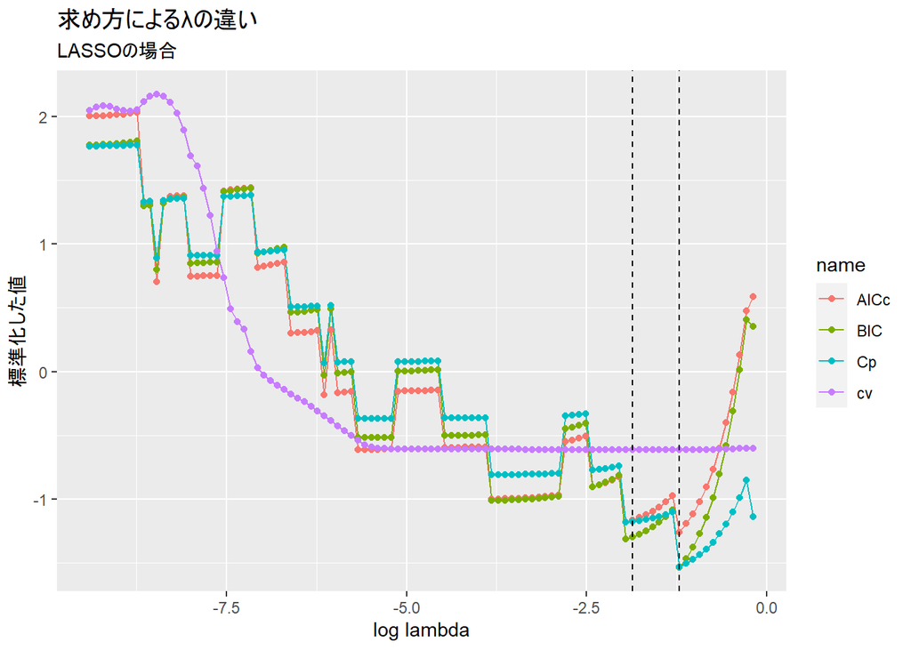

```r
bind_rows(
  data.frame(
    name = "AICc",
    value = scale(car_ic_lambda_lasso$lambda_AICc),
    lambda = log(car_fit_lasso$lambda)
    ),
  data.frame(
    name = "BIC",
    value = scale(car_ic_lambda_lasso$lambda_BIC),
    lambda = log(car_fit_lasso$lambda)
    ),
  data.frame(
    name = "Cp",
    value = scale(car_ic_lambda_lasso$lambda_Cp),
    lambda = log(car_fit_lasso$lambda)
    ),
  data.frame(
    name = "cv",
    value = scale(car_fit_lasso_cv$cvm),
    lambda = log(car_fit_lasso_cv$lambda)
    )
  ) |>
  ggplot(aes(x = lambda, y = value, color = name)) +
  geom_line() +
  geom_point() +
  geom_vline(
    xintercept = c(
      log(car_ic_lambda_lasso$lambda_Cp_best),
      log(car_fit_lasso_cv$lambda.min)),
    linetype = 2
    ) +
  labs(
    title = "求め方によるλの違い",
    subtitle = "LASSOの場合",
    x = "log lambda",
    y = "標準化した値"
    )
```

こんどはエラスティックネット回帰を行う。

エラスティックネットではλの他にαの値もハイパーパラメータとなる。

適切なλとαの値をCVと情報量規準で求める。

エラスティックネットのためのλとαの探索関数を定義。

CV版。

```r
# cva.glmnet()の出力を受け取る
get_cv_best_alpha_lambda <- function(cva_model) {
  n <- cva_model$alpha |> length()

  res <- map(
    1:n,
    \(list_no) data.frame(
      best_alpah = cva_model |> pluck("alpha", list_no),
      best_lambda = cva_model |> pluck("modlist", list_no, "lambda"),
      MSE = cva_model |> pluck("modlist", list_no, "cvm")
      )
    ) |>
    list_rbind() |>
    slice_min(MSE) |>
    dplyr::select(best_alpah, best_lambda)

  return(res)
}
```

情報量規準版。

```r
# cva.glmnet()の出力を受け取る
get_ic_best_alpha_lambda <- function(cva_model) {

  n <- cva_model$alpha |>
    length()

  ics <- map(
    1:n,
    \(list_no) cva_model |>
      pluck("modlist", list_no, "glmnet.fit") |>
      ic_glmnet()
    )

  df_ic <- map(
    1:n,
    \(list_no) data.frame(
      best_alpah = cva_model |> pluck("alpha", list_no),
      best_lambda = cva_model |> pluck("modlist", list_no, "lambda"),
      AICc = ics |> pluck(list_no, "lambda_AICc"),
      BIC = ics |> pluck(list_no, "lambda_BIC"),
      Cp = ics |> pluck(list_no, "lambda_Cp")
      )
    ) |>
    list_rbind()

  df_ic_best <- list(
    AICc_best_alpha = df_ic |> slice_min(AICc) |> pull(best_alpah),
    AICc_best_lambda = df_ic |> slice_min(AICc) |> pull(best_lambda),
    BIC_best_alpha = df_ic |> slice_min(BIC) |> pull(best_alpah),
    BIC_best_lambda = df_ic |> slice_min(BIC) |> pull(best_lambda),
    Cp_best_alpha = df_ic |> slice_min(Cp) |> pull(best_alpah),
    Cp_best_lambda = df_ic |> slice_min(Cp) |> pull(best_lambda)
  )

  return(df_ic_best)

 }
```

では、最適なαとλを求めてみる。

```r
car_fit_glmnet_L1L2 <- cva.glmnet(
  dist ~ poly(speed, degree = 9, raw = TRUE),
  data = cars_train,
  nfolds = 5
  ) |>
  with_seed(2, code = _)
```

CV版

```r
car_en_cv_best_alpha_lambda <- car_fit_glmnet_L1L2 |>
  get_cv_best_alpha_lambda()

car_en_cv_best_alpha_lambda
```

| best_alpah | best_lambda |
| --- | --- |
| 1 | 0.1554653 |

情報量規準版。

```r
car_en_ic_best_alpha_lambda <- car_fit_glmnet_L1L2 |>
  get_ic_best_alpha_lambda()

car_en_ic_best_alpha_lambda
```

```
## $AICc_best_alpha
## [1] 1
##
## $AICc_best_lambda
## [1] 0.2981684
##
## $BIC_best_alpha
## [1] 1
##
## $BIC_best_lambda
## [1] 0.2981684
##
## $Cp_best_alpha
## [1] 1
##
## $Cp_best_lambda
## [1] 0.2981684
```

今回はいずれも最適なαは1となりLASSO回帰と変わらないので、エラスティックネット回帰は行わないことにする。

それぞれの方法で求めたλを当てはめて、Ridge、LASSO、適応的LASSO、それぞれのモデルを作る。

```r
# CV
car_fit_ridge_min <- glmnet(
  dist ~ poly(speed, degree = 9, raw = TRUE),
  data = cars_train, alpha = 0, lambda = car_fit_ridge_cv$lambda.min
  )

car_fit_lasso_min <- glmnet(
  dist ~ poly(speed, degree = 9, raw = TRUE),
  data = cars_train, alpha = 1, lambda = car_fit_lasso_cv$lambda.min
  )

car_fit_alasso_min <- cars_train |>
  glmnet(dist ~ poly(speed, degree = 9, raw = TRUE), data = _, alpha = 1,
         lambda = car_fit_alasso_cv$lambda.min,
         penalty.factor = 1 / abs(lm_std_coef$estimate)
  )

# 情報量規準
car_fit_lasso_ic <- glmnet(
  dist ~ poly(speed, degree = 9, raw = TRUE),
  data = cars_train, alpha = 1, lambda = car_ic_lambda_lasso$lambda_Cp_best
  )

car_fit_ridge_ic <- glmnet(
  dist ~ poly(speed, degree = 9, raw = TRUE),
  data = cars_train, alpha = 1, lambda = car_ic_lambda_ridge$lambda_Cp_best
  )

car_fit_alasso_ic <- glmnet(
  dist ~ poly(speed, degree = 9, raw = TRUE),
  data = cars_train, alpha = 1, lambda = car_ic_lambda_alasso$lambda_Cp_best,
  penalty.factor = 1 / abs(lm_std_coef$estimate)
  )
```

各モデルの偏回帰係数を確認する。

LASSOでは多くの偏回帰係数がゼロになっていることが分かる。

```r
coeffs_raw <- tibble(
  vars = car_fit_lm |> coef() |> names(),
  lm = car_fit_lm |> coef() |> round(4),
  lasso_cv = car_fit_lasso_min |> coef() |> as.vector() |> round(3),
  lasso_ic = car_fit_lasso_ic |> coef() |> as.vector() |> round(3),
  ridge_cv = car_fit_ridge_min |> coef() |> as.vector() |> round(3),
  ridge_ic = car_fit_ridge_ic |> coef() |> as.vector() |> round(3),
  alasso = car_fit_alasso |> coef() |> as.vector() |> round(3),
  alasso_cv = car_fit_alasso_min |> coef() |> as.vector() |> round(3),
  alasso_ic = car_fit_alasso_ic |> coef() |> as.vector() |> round(3)
)

coeffs_raw
```

| vars | lm | lasso_cv | lasso_ic | ridge_cv | ridge_ic | alasso | alasso_cv | alasso_ic |
| --- | --- | --- | --- | --- | --- | --- | --- | --- |
| (Intercept) | -0.2940 | -0.042 | -0.044 | -0.081 | -0.093 | -0.083 | -0.099 | -0.083 |
| poly(speed, degree = 9, raw = TRUE)1 | 0.8094 | 0.619 | 0.534 | 0.192 | 0.630 | 0.410 | 0.483 | 0.410 |
| poly(speed, degree = 9, raw = TRUE)2 | 1.9877 | 0.000 | 0.000 | 0.036 | 0.054 | 0.000 | 0.000 | 0.000 |
| poly(speed, degree = 9, raw = TRUE)3 | 0.2754 | 0.024 | 0.000 | 0.052 | 0.053 | 0.000 | 0.000 | 0.000 |
| poly(speed, degree = 9, raw = TRUE)4 | -3.7661 | 0.000 | 0.000 | 0.008 | 0.000 | 0.025 | 0.031 | 0.025 |
| poly(speed, degree = 9, raw = TRUE)5 | -1.4687 | 0.000 | 0.000 | 0.009 | 0.000 | 0.022 | 0.023 | 0.022 |
| poly(speed, degree = 9, raw = TRUE)6 | 2.1098 | 0.000 | 0.000 | 0.001 | 0.000 | 0.000 | 0.000 | 0.000 |
| poly(speed, degree = 9, raw = TRUE)7 | 1.0111 | 0.000 | 0.000 | 0.001 | 0.000 | 0.000 | 0.000 | 0.000 |
| poly(speed, degree = 9, raw = TRUE)8 | -0.3501 | 0.000 | 0.000 | 0.000 | 0.000 | 0.000 | 0.000 | 0.000 |
| poly(speed, degree = 9, raw = TRUE)9 | -0.1763 | 0.000 | 0.000 | 0.000 | 0.000 | 0.000 | 0.000 | 0.000 |

偏回帰係数の可視化

いずれも線形回帰よりも非常に小さい係数。

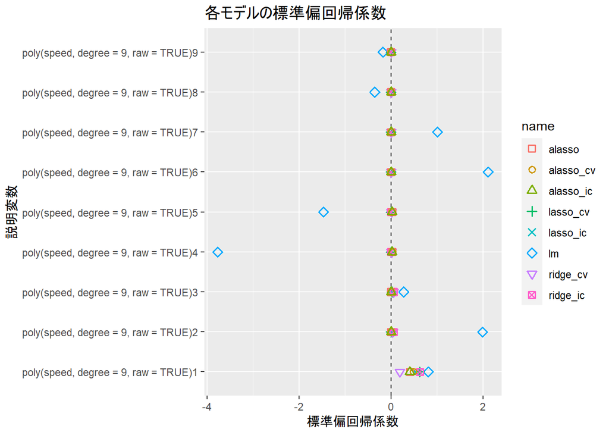

```r
coeffs_raw |>
  slice(-1) |>
  pivot_longer(!vars) |>
#  ggplot(aes(x = vars, y = value, color = name, group = name)) +
#  geom_hline(yintercept = 0, linetype = 2) +
#  geom_point(size = 4) +
  ggplot(aes(x = vars, y = value, color = name, shape = name)) +
  geom_hline(yintercept = 0, linetype=2) +
  geom_point(size = 2, stroke = 1) +
  scale_shape_manual(values = 0:7) +
  coord_flip() +
  labs(title = "各モデルの標準偏回帰係数", y = "標準偏回帰係数", x = "説明変数")
```

各モデルのあてはまりを可視化する。

線形回帰以外はだいぶ過学習を抑えられている様子。

ただ、LASSOは逆にアンダーフィットしている様子。

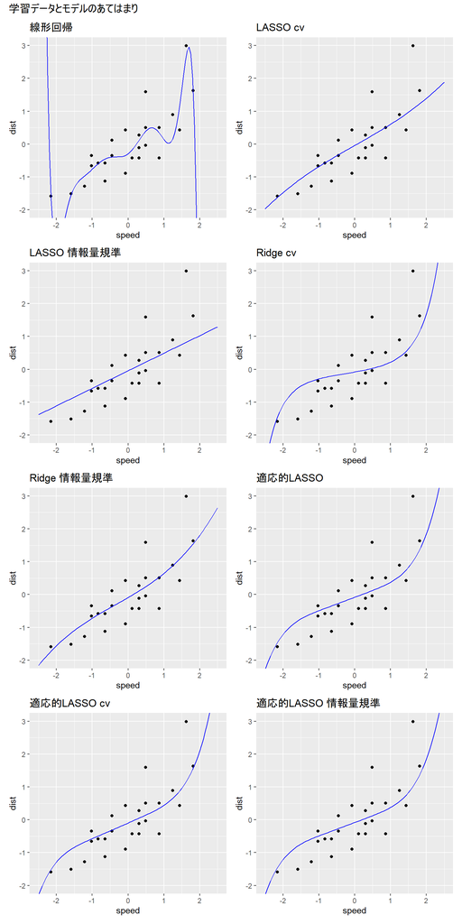

```r
newcars <- data.frame(speed = seq(-2.5, 2.5, 0.05))

pred <- tibble(
  speed = newcars$speed,
  pred_lm = predict(car_fit_lm, newdata = newcars),
  pred_lasso_min = predict(car_fit_lasso_min, newdata = newcars),
  pred_lasso_ic = predict(car_fit_lasso_ic, newdata = newcars),
  pred_ridge_min = predict(car_fit_ridge_min, newdata = newcars),
  pred_ridge_ic = predict(car_fit_ridge_ic, newdata = newcars),
  pred_alasso = predict(car_fit_alasso, newdata = newcars),
  pred_alasso_min = predict(car_fit_alasso_min, newdata = newcars),
  pred_alasso_ic = predict(car_fit_alasso_ic, newdata = newcars)
  )

my_fit_plot <- function(df, var, maintitle) {
  ggplot() +
    geom_point(cars_train, mapping = aes(x = speed, y = dist)) +
    geom_line(df, mapping = aes(x = speed, y = var), color = "blue") +
    coord_cartesian(xlim = c(-2.5, 2.5), ylim = c(-2, 3)) +
    labs(title = maintitle)
}

plots <- list(
  my_fit_plot(pred, pred$pred_lm, "線形回帰"),
  my_fit_plot(pred, pred$pred_lasso_min, "LASSO cv"),
  my_fit_plot(pred, pred$pred_lasso_ic, "LASSO 情報量規準"),
  my_fit_plot(pred, pred$pred_ridge_min, "Ridge cv"),
  my_fit_plot(pred, pred$pred_ridge_ic, "Ridge 情報量規準"),
  my_fit_plot(pred, pred$pred_alasso, "適応的LASSO"),
  my_fit_plot(pred, pred$pred_alasso_min, "適応的LASSO cv"),
  my_fit_plot(pred, pred$pred_alasso_ic, "適応的LASSO 情報量規準")
)

plots |>
  wrap_plots(ncol = 2) +
  plot_annotation(title = '学習データとモデルのあてはまり')
```

#### 汎化性能の確認

これで一通りのモデルができたので、ここから検証用データを使って汎化性能を確認する。

評価指標は以下の二つ。

- RMSE: 外れ値に敏感で、一部に大きな誤差があると評価が下がる。
- MAE: 外れ値はあまり考慮せず、全体として平均的に評価する。

汎化性能で言えばLASSOのCV、適応的LASSOのCV、Ridge情報量規準が良い

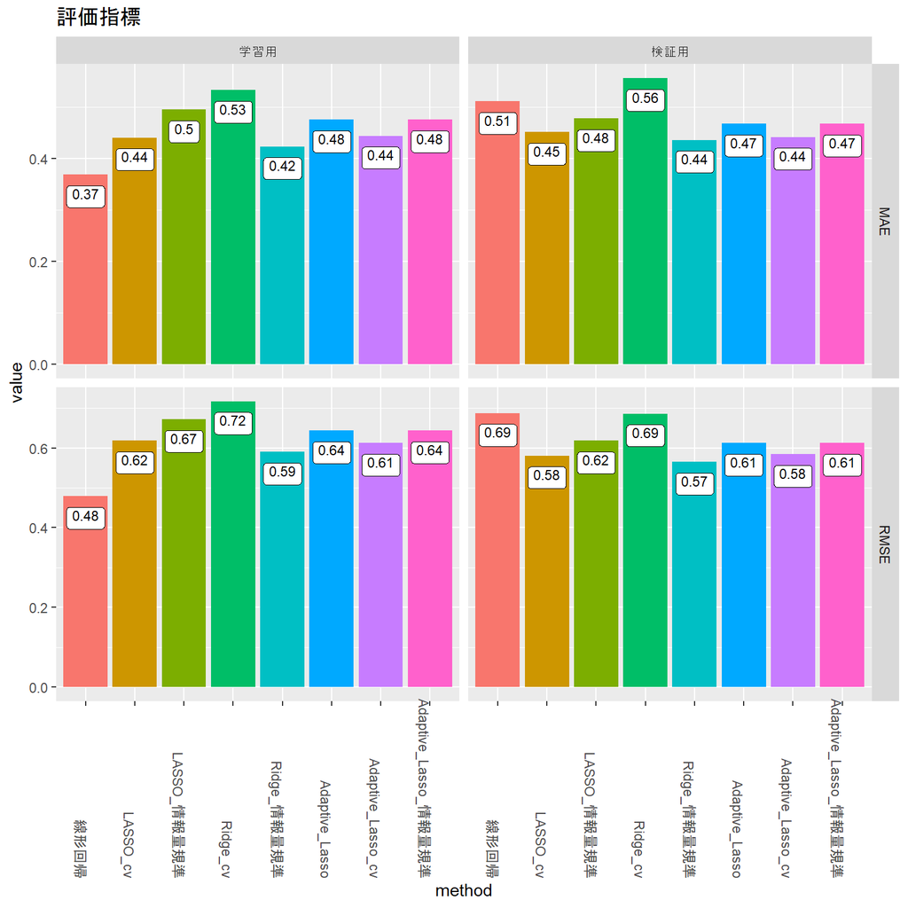

```r
car_models <- list(
  car_fit_lm,
  car_fit_lasso_min,
  car_fit_lasso_ic,
  car_fit_ridge_min,
  car_fit_ridge_ic,
  car_fit_alasso,
  car_fit_alasso_min,
  car_fit_alasso_ic
  )

car_methods <- c(
  "線形回帰", "LASSO_cv", "LASSO_情報量規準", "Ridge_cv",
  "Ridge_情報量規準", "Adaptive_Lasso", "Adaptive_Lasso_cv",
  "Adaptive_Lasso_情報量規準"
  )

tibble(
  method = car_methods,
  学習用_MAE = car_models |>
    map_dbl(\(x) MLmetrics::MAE(predict(x, cars_train), cars_train$dist)),
  検証用_MAE = car_models |>
    map_dbl(\(x) MLmetrics::MAE(predict(x, cars_test), cars_test$dist)),
  学習用_RMSE = car_models |>
    map_dbl(\(x) MLmetrics::RMSE(predict(x, cars_train), cars_train$dist)),
  検証用_RMSE = car_models |>
    map_dbl(\(x) MLmetrics::RMSE(predict(x, cars_test), cars_test$dist))
) |>
  pivot_longer(!method) %>%
  mutate(
    type = stringr::str_split(.$name, "_", simplify = TRUE)[, 1] |>
      factor(levels = c("学習用", "検証用")),
    measure = stringr::str_split(.$name, "_", simplify = TRUE)[, 2] |>
      factor(levels = c("MAE", "RMSE")),
    method = method |>
      factor(levels = car_methods)
  ) |>
  ggplot(aes(x = method, y = value, group = 1, label = round(value, 2))) +
  geom_col(aes(fill = method)) +
  geom_label(size = 3, vjust = 1.5) +
  facet_grid(vars(measure), vars(type), scales = "free") +
  labs(title = "評価指標") +
  theme(
    axis.text.x = element_text(angle = 270, hjust = 1),
    legend.position = "none"
  )
```

#### 汎化性能の安定性を確認

学習データと検証データのサンプリングを変えて、汎化性能の安定性を確認する。

```r
# シミュレーション用関数を定義する
# 乱数種を与える
sim_f_car <- function(seed) {

  car_split_data <- cars_std |>
    initial_split(prop = 0.5, strata = "dist") |>
    with_seed(seed = seed, code = _)

  car_train <- car_split_data |> training()

  car_test <- car_split_data |> testing()

  # lm
  car_fit_lm <- lm(
    dist ~ poly(speed, degree = 9, raw = TRUE),
    data = cars_train
    )

  # lasso_cv
  car_fit_lasso_cv <- cv.glmnet(
    dist ~ poly(speed, degree = 9, raw = TRUE),
    data = cars_train,
    alpha = 1,
    nfolds = 5
    )

  car_fit_lasso_cv <- glmnet(
    dist ~ poly(speed, degree = 9, raw = TRUE),
    data = cars_train,
    alpha = 1,
    lambda = car_fit_lasso_cv$lambda.min
    )

  # ridge_cv
  car_fit_ridge_cv <- cv.glmnet(
    dist ~ poly(speed, degree = 9, raw = TRUE),
    data = cars_train,
    alpha = 0,
    nfolds = 5
    )

  car_fit_ridge_cv <- glmnet(
    dist ~ poly(speed, degree = 9, raw = TRUE),
    data = cars_train,
    alpha = 0,
    lambda = car_fit_ridge_cv$lambda.min
    )

  # lasso_ic
  car_ic_lambda_lasso <- glmnet(
    dist ~ poly(speed, degree = 9, raw = TRUE),
    data = cars_train,
    alpha = 1
    ) |>
    ic_glmnet()

  car_fit_lasso_AICc <- glmnet(
    dist ~ poly(speed, degree = 9, raw = TRUE),
    data = cars_train,
    alpha = 1,
    lambda = car_ic_lambda_lasso$lambda_AICc_best
    )

  car_fit_lasso_BIC <- glmnet(
    dist ~ poly(speed, degree = 9, raw = TRUE),
    data = cars_train,
    alpha = 1,
    lambda = car_ic_lambda_lasso$lambda_BIC_best
    )

  car_fit_lasso_Cp <- glmnet(
    dist ~ poly(speed, degree = 9, raw = TRUE),
    data = cars_train,
    alpha = 1,
    lambda = car_ic_lambda_lasso$lambda_Cp_best
    )

  # ridge_ic
  car_ic_lambda_ridge <- glmnet(
    dist ~ poly(speed, degree = 9, raw = TRUE),
    data = cars_train,
    alpha = 0
    ) |>
    ic_glmnet()

  car_fit_ridge_AICc <- glmnet(
    dist ~ poly(speed, degree = 9, raw = TRUE),
    data = cars_train,
    alpha = 0,
    lambda = car_ic_lambda_ridge$lambda_AICc_best
    )

  car_fit_ridge_BIC <- glmnet(
    dist ~ poly(speed, degree = 9, raw = TRUE),
    data = cars_train,
    alpha = 0,
    lambda = car_ic_lambda_ridge$lambda_BIC_best
    )

  car_fit_ridge_Cp <- glmnet(
    dist ~ poly(speed, degree = 9, raw = TRUE),
    data = cars_train,
    alpha = 0,
    lambda = car_ic_lambda_ridge$lambda_Cp_best
    )

  # alasso
  lm_std_coef <- cars_train |>
    scale() |>
    as.data.frame() |>
    lm(dist ~ poly(speed, degree = 9, raw = TRUE), data = _) |>
    tidy() |>
    select(estimate) |>
    slice(-1)

  # 理論的ラムダを当てはめ
  car_fit_alasso <- cars_train %>%
    glmnet(
      dist ~ poly(speed, degree = 9, raw = TRUE),
      data = .,
      alpha = 1,
      lambda = 5 / nrow(.)^(3 / 4),
      penalty.factor = 1 / abs(lm_std_coef$estimate)
    )

  # CVでlambda探索
  car_fit_alasso_cv <- cv.glmnet(
    dist ~ poly(speed, degree = 9, raw = TRUE),
    data = cars_train,
    alpha = 1,
    nfolds = 5,
    penalty.factor = 1 / abs(lm_std_coef$estimate)
    )

  car_fit_alasso_cv <- glmnet(
    dist ~ poly(speed, degree = 9, raw = TRUE),
    data = cars_train, alpha = 1,
    lambda = car_fit_alasso_cv$lambda.min,
    penalty.factor = 1 / abs(lm_std_coef$estimate)
    )

  # 情報量規準
  car_fit_alasso_full <- glmnet(
    dist ~ poly(speed, degree = 9, raw = TRUE),
    data = cars_train, alpha = 1,
    penalty.factor = 1 / abs(lm_std_coef$estimate)
    )

  car_ic_lambda_alasso <- car_fit_alasso_full |>
    ic_glmnet()

  car_fit_alasso_aicc <- cars_train |>
    glmnet(
      dist ~ poly(speed, degree = 9, raw = TRUE),
      data = _,
      alpha = 1,
      lambda = car_ic_lambda_alasso$lambda_AICc_best,
      penalty.factor = 1 / abs(lm_std_coef$estimate)
      )

  car_fit_alasso_bic <- cars_train |>
    glmnet(
      dist ~ poly(speed, degree = 9, raw = TRUE),
      data = _,
      alpha = 1,
      lambda = car_ic_lambda_alasso$lambda_BIC_best,
      penalty.factor = 1 / abs(lm_std_coef$estimate)
      )

  car_fit_alasso_cp <- cars_train |>
    glmnet(
      dist ~ poly(speed, degree = 9, raw = TRUE),
      data = _,
      alpha = 1,
      lambda = car_ic_lambda_alasso$lambda_Cp_best,
      penalty.factor = 1 / abs(lm_std_coef$estimate)
      )

  # 評価
  models_house <- list(
    car_fit_lm,
    car_fit_lasso_cv, car_fit_lasso_AICc, car_fit_lasso_BIC, car_fit_lasso_Cp,
    car_fit_ridge_cv, car_fit_ridge_AICc, car_fit_ridge_BIC, car_fit_ridge_Cp,
    car_fit_alasso,
    car_fit_alasso_cv, car_fit_alasso_aicc, car_fit_alasso_bic, car_fit_alasso_cp
  )

  df <- data.frame(
    methods = c(
      "線形回帰",
      "LASSO_cv", "LASSO_AICc", "LASSO_BIC", "LASSO_Cp",
      "Ridge_cv", "Ridge_AICc", "Ridge_BIC", "Ridge_Cp",
      "適応的LASSO",
      "適応的LASSO_cv", "適応的LASSO_AICc", "適応的LASSO_BIC", "適応的LASSO_Cp"
      ),
    RMSE = models_house |>
      map_dbl(\(x) MLmetrics::RMSE(predict(x, car_test), car_test$dist)),
    MAE = models_house |>
      map_dbl(\(x) MLmetrics::MAE(predict(x, car_test), car_test$dist))
  )

  return(df)
}
```

実行。

```r
j <- 300
sim_data <- map(1:j, \(x) sim_f_car(x)) |> #, .progress = TRUE
  list_rbind()
```

結果の可視化。

CVはバラツキが大きい。情報量規準は安定している。当たり前か……

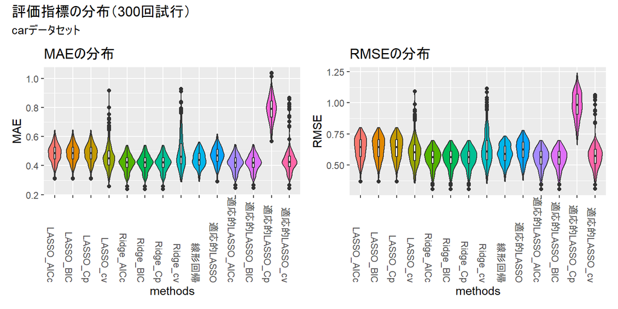

```r
p1 <- sim_data |>
  ggplot(aes(x = methods, y = MAE)) +
  geom_violin(aes(fill = methods)) +
  geom_boxplot(width = 0.1) +
  labs(title = "MAEの分布") +
  theme(
    axis.text.x = element_text(angle = 270, hjust = 1),
    legend.position = "none"
  )

p2 <- sim_data |>
  ggplot(aes(x = methods, y = RMSE)) +
  geom_violin(aes(fill = methods)) +
  geom_boxplot(width = 0.1) +
  labs(title = "RMSEの分布") +
  theme(
    axis.text.x = element_text(angle = 270, hjust = 1),
    legend.position = "none"
  )

p1 + p2 +
  plot_annotation(
    title = "評価指標の分布（300回試行）",
    subtitle = "carデータセット"
    )
```

ともかく、多項式回帰などで過学習してしまうケースではRidge回帰やLASSO回帰を使うことで、モデルは線形回帰のまま、汎化性能の高いモデルが得られることは分かった。

TOPへ戻る